# A3: Incarceration

### Summary Information

- What is the average value of total population across all the counties in 2003?
- What is the average value of total population across all the counties in 2007?
- When is female population the highest in Pacific division?
- Which county has the highest male population in 2018?
- How much has total population change over the last 30 years (1988-2018)?

Summary : To summarize the data, I proposed 5 questions. The average value of total population across all the counties in 2003 is 9.2418508^{4}. The average value of total population across all the counties in 2007 is 9.5962102^{4}. 2015 is the time that female population is the the highest in Pacific division. Los Angeles County is the county that has the highest male population. The total jail population has changed 3.9496509^{5} over last 30 years, from 1988 to 2018.

### The Dataset

Who collected the data?

The data was collected by BJS, which are the Census of Jails (COJ), and the Annual Survey of Jails (ASJ). Then, the data was released by Vera.

How was the data collected or generated?  
This data combined data from different data sources. Vera completed work on a companion county-level prison dataset, examined in The New Dynamics of Mass Incarceration, that drew on the BJS National Corrections Reporting Program (NCRP) data collection.

Why was the data collected?  
Because they want to make the data with visualization, and then to utilize data to answer more question. For example, county-level variability makes for more robust, theoretically-grounded studies of the high rates of incarceration seen across the United States.

How many observations (rows) are in your data?  
There are 153811 observations in the data.

How many features (columns) are in the data?  
There are 121 columns in the data

What, if any, ethical questions or questions of power do you need to consider when working with this data?  
I think the data might be too specific, so people can know who is this one even though teh data is anonymous.Because for every row, it contains enough information that people.Therefore, the privacy might be one of the ethical question.

What are possible limitations or problems with this data? (at least 200 words)

The data is very comprehensive, which contains many specific information for people to investigate. However, the limitations still occur. There are several missing data, which makes the dataset incomplete. For example, the data has many “NA” for some race population in previous years. Incomplete data can prevent many research question from proceeding smoothly, even if only a small part of it is missing. And with so many applications, I am familiar with the function of “na.rm”. It helps us to clean the data.

### Trends Over Time Chart

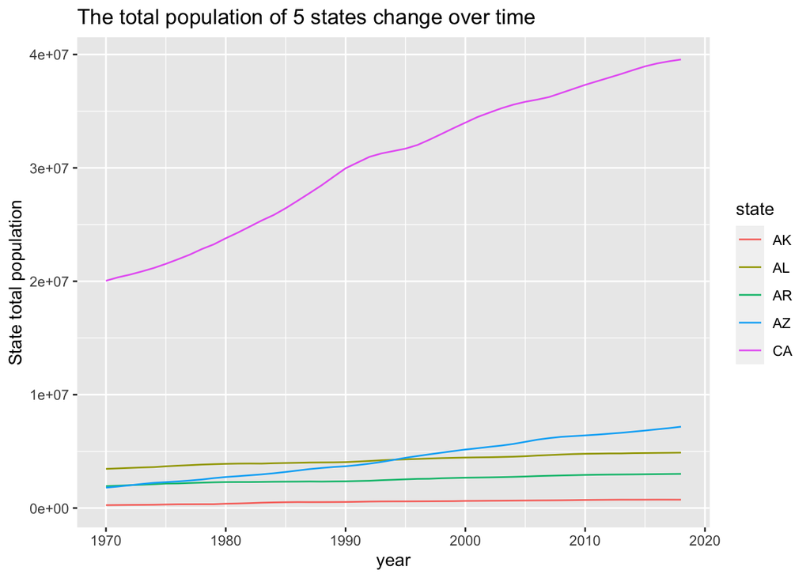

In Chart 1, I display the change trend of five state’s total population over time. I choose these five states because they are top 5 alphabetically. As we can see form the chart, 5 states that I picked has increasing total population, but different in speed. California has the highest number of total population than other 4 states obviously.

### Variable Comparison Chart

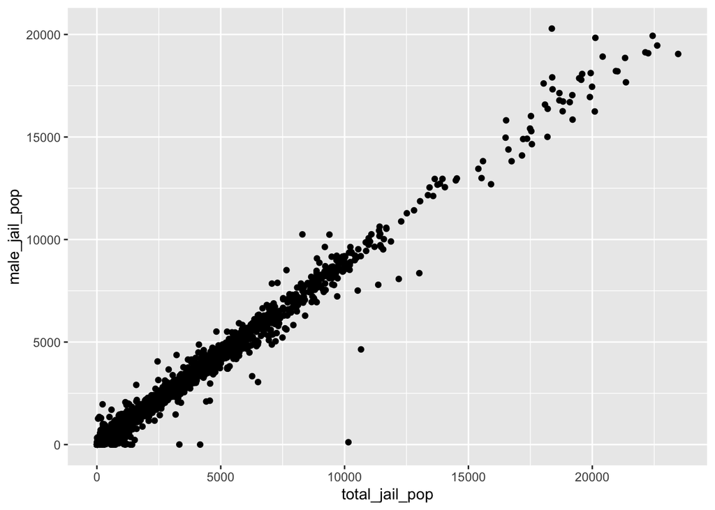

```
## $x
## [1] "Total Jail Population"
##
## $y
## [1] "Male Jail Population"
##
## $title
## [1] "The relationship between total jail population and male jail popolation"
##
## attr(,"class")
## [1] "labels"
```

In Chart 2, I use scatter plot to reveal the relationship between total jail population and male population. As we can see, they are strong positive related. Also, the slope the line is close to 1, it indicates the total population and male population in the jail are increasing together.

### Map

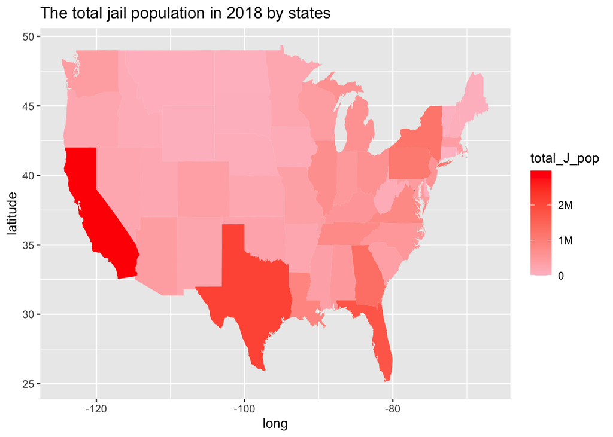

In chart 3, I create a map to investigate where has the most number of jail population geographically. The total number of people in the jail is indicated by the shade of color, from red to pink, from most to least. As we can see, California has the highest number of total jail population.